```python
# Maxim Kapelina, Layke Martin, Sahib Srivastava final project
# Performing analysis on stock market data
```

# Part 1: Data Collection and Organization

The goal of this project is to highlight the effects of the Coronavirus on the stock market. To accurately do this, we will analyze the companies in the S&P500, a collection of the 500 highest market cap companies in the world. A company’s market cap, short for its “market capitalization”, is the total value of a company calculated by multiplying the number of shares the company has by the price of each share. Since stock prices can fluctuate quite a bit however, once a company gets into the S&P 500, it is guaranteed a spot on that list for at least a quarter of a year. The S&P 500 companies analyzed in this project are from the last quarter of 2020. More details on the topic of stocks, the S&P 500, stock analysis, and the Coronavirus can be found at the following links, respectively: https://www.investor.gov/introduction-investing/investing-basics/investment-products/stocks https://en.wikipedia.org/wiki/S%26P_500_Index https://www.investopedia.com/terms/s/stock-analysis.asp https://www.who.int/health-topics/coronavirus

```python
import pandas as pd
from bs4 import BeautifulSoup, SoupStrainer
import datetime as dt
import grequests
import numpy as np
import matplotlib.pyplot as plt
import math
```

The first part of the data collection process is to get an updated list of all companies and their associated tickers from an up to date website. To do this, I scraped the data from the wikipedia article linked in the beginning of this tutorial about the S&P 500. A ticker is a 1-5 character abbreviation used to represent a company in the stock market. I need the tickers to perform later requests to yahoo finance to get more data on the stocks of each company in the S&P 500.

```python
# Get the tickers and names of all S&P 500 companies
rs = (grequests.get(u) for u in ['http://en.wikipedia.org/wiki/List_of_S%26P_500_companies'])
soup = BeautifulSoup(grequests.map(rs)[0].text, 'lxml')
table = soup.find('table', {'class': 'wikitable sortable'})
tickers = []
for row in table.findAll('tr')[1:]:
    tickers.append(row.findAll('td')[0].text[:-1])

names = []
for row in table.findAll('tr')[1:]:
    names.append(row.findAll('td')[1].text)

tickers = list(filter(lambda ticker: '.' not in ticker, tickers))
tickers
```

```
['MMM',
 'ABT',
 'ABBV',
 'ABMD',
 'ACN',
 'ATVI',
 'ADBE',
 'AMD',
 'AAP',
 'AES',
 'AFL',
 'A',
 'APD',
 'AKAM',
 'ALK',
 'ALB',
 'ARE',
 'ALXN',
 'ALGN',
 'ALLE',
 'LNT',
 'ALL',
 'GOOGL',
 'GOOG',
 'MO',
 'AMZN',
 'AMCR',
 'AEE',
 'AAL',
 'AEP',
 'AXP',
 'AIG',
 'AMT',
 'AWK',
 'AMP',
 'ABC',
 'AME',
 'AMGN',
 'APH',
 'ADI',
```

[output cut: 448 more lines]

```
 'WRK',
 'WY',
 'WHR',
 'WMB',
 'WLTW',
 'WYNN',
 'XEL',
 'XRX',
 'XLNX',
 'XYL',
 'YUM',
 'ZBRA',
 'ZBH',
 'ZION',
 'ZTS']
```

The next part of the data collection process is to get data on each S&P 500 company’s stock price, price to earnings ratio, market cap, volume, and earnings per share. I used the yahoo finance quote page for each ticker in the list of tickers from above to format the proper url and scrape the necessary data.

```python
# Get surface level data from yahoo finance on all tickers by performing web scraping
req_urls = []
for ticker in tickers:
    req_urls.append('https://finance.yahoo.com/quote/' + ticker)

rs = (grequests.get(u) for u in req_urls)
ticker_responses = grequests.map(rs)
```

Now that I have the quote data, I need to parse it. For this step, I loop through each response associated with each ticker from the above yahoo finance requests and parse out the current price. Then, I append the list of current prices as a column to a newly created dataframe containing columns for Ticker, Company Name, and Current Price.

```python
# Parse current price data into dataframe
stock_data = pd.DataFrame()
stock_data['Ticker'] = pd.Series(tickers)
stock_data['Name'] = pd.Series(names)

ticker_prices = []
for res in ticker_responses:
    ticker_soup = BeautifulSoup(res.text, 'lxml')
    try:
        ticker_prices.append(ticker_soup.find('div', {'data-reactid': '49'}).find("span").text)
    except:
        ticker_prices.append(np.nan)

stock_data['Current Price'] = pd.Series(ticker_prices)
stock_data
```

|  | Ticker | Name | Current Price |
| --- | --- | --- | --- |
| 0 | MMM | 3M Company | 175.41 |
| 1 | ABT | Abbott Laboratories | 107.34 |
| 2 | ABBV | AbbVie Inc. | 104.64 |
| 3 | ABMD | ABIOMED Inc | 274.14 |
| 4 | ACN | Accenture plc | 247.45 |
| ... | ... | ... | ... |
| 498 | YUM | Xilinx | 107.42 |
| 499 | ZBRA | Xylem Inc. | 377.41 |
| 500 | ZBH | Yum! Brands Inc | 148.85 |
| 501 | ZION | Zebra Technologies | 41.87 |
| 502 | ZTS | Zimmer Biomet | 160.62 |

503 rows × 3 columns

Next, I need to parse out the rest of the quote data. I used the same process as the part above to parse the P/E ratio, market cap, trade volume, and earnings per share into the dataframe.

```python
# Parse PE ratios, market caps, trading volumes and EPS into the dataframe

ticker_pe_ratios = []
ticker_mcap = []
ticker_volume = []
ticker_eps = []
for res in ticker_responses:
    ticker_soup = BeautifulSoup(res.text, 'lxml')
    ticker_pe_ratios.append(ticker_soup.find('table', {'class': 'W(100%) M(0) Bdcl(c)'}).find('td', {'data-test': 'PE_RATIO-value'}).text)
    ticker_mcap.append(ticker_soup.find('table', {'class': 'W(100%) M(0) Bdcl(c)'}).find('td', {'data-test': 'MARKET_CAP-value'}).text)
    ticker_volume.append(ticker_soup.find('table', {'class': 'W(100%)'}).find('td', {'data-test': 'TD_VOLUME-value'}).text)
    ticker_eps.append(ticker_soup.find('table', {'class': 'W(100%) M(0) Bdcl(c)'}).find('td', {'data-test': 'EPS_RATIO-value'}).text)



stock_data['P/E Ratio'] = pd.Series(ticker_pe_ratios)
stock_data['Market Cap'] = pd.Series(ticker_mcap)
stock_data['Volume'] = pd.Series(ticker_volume)
stock_data['EPS'] = pd.Series(ticker_eps)
stock_data
```

|  | Ticker | Name | Current Price | P/E Ratio | Market Cap | Volume | EPS |
| --- | --- | --- | --- | --- | --- | --- | --- |
| 0 | MMM | 3M Company | 175.41 | 20.57 | 101.18B | 1,949,884 | 8.53 |
| 1 | ABT | Abbott Laboratories | 107.34 | 56.76 | 190.245B | 4,458,721 | 1.89 |
| 2 | ABBV | AbbVie Inc. | 104.64 | 22.89 | 184.739B | 9,182,062 | 4.57 |
| 3 | ABMD | ABIOMED Inc | 274.14 | 60.25 | 12.388B | 303,040 | 4.55 |
| 4 | ACN | Accenture plc | 247.45 | 31.34 | 163.951B | 2,247,981 | 7.89 |
| ... | ... | ... | ... | ... | ... | ... | ... |
| 498 | YUM | Xilinx | 107.42 | 31.19 | 32.405B | 2,412,382 | 3.44 |
| 499 | ZBRA | Xylem Inc. | 377.41 | 43.08 | 20.122B | 474,327 | 8.76 |
| 500 | ZBH | Yum! Brands Inc | 148.85 | N/A | 30.853B | 743,121 | -0.74 |
| 501 | ZION | Zebra Technologies | 41.87 | 17.70 | 6.867B | 1,681,555 | 2.37 |
| 502 | ZTS | Zimmer Biomet | 160.62 | 46.29 | 76.338B | 1,440,917 | 3.47 |

503 rows × 7 columns

Now that the quote data has been parsed, it’s time to get some more interesting data. To do this, I will perform the same process of requesting data from yahoo finance as I did for the quote data, but this time I will be getting historical data. The specific data I am getting is the stock price on the first of the month for every month in the past year for each of the 500 companies in our analysis. This request is also done asynchronously to improve the efficiency of this portion of the data collection.

```python
# Get historical data on all tickers from yahoo finance

req_urls = []
hist_data_url = '/history?period1=1577750400&period2=1607299200&interval=1mo&filter=history&frequency=1mo&includeAdjustedClose=true'
for ticker in tickers:
    req_urls.append('https://finance.yahoo.com/quote/' + ticker + hist_data_url)

rs = (grequests.get(u) for u in req_urls)
history_responses = grequests.map(rs)
```

Now that I have made all the requests for the historical data and gotten my responses, I need to once again parse out the data from the scraped HTML. To do this, I go through each get response, extract the data, and put it into an ordered list, with the first element being january 1st and the last being december 1st. Then, that list is added to a list of lists, which is then added as a column of the dataframe.

```python
# Parse historical data into dataframe

parse_only_hist = SoupStrainer('table', {'data-test': 'historical-prices'})
hist_data = [[]]
for res in history_responses:
    hist_soup = BeautifulSoup(res.text, 'lxml', parse_only=parse_only_hist)
    all_closes = map(lambda r: r.text, hist_soup.find_all('td', {'class': 'Py(10px) Pstart(10px)'}))
    all_closes = list(map(lambda t: t[1], list(filter(lambda r: r[0] % 6 == 3, enumerate(all_closes)))))
    hist_data.append(all_closes[::-1])

stock_data['Historical Prices'] = pd.Series(hist_data[1:])
stock_data
```

|  | Ticker | Name | Current Price | P/E Ratio | Market Cap | Volume | EPS | Historical Prices |
| --- | --- | --- | --- | --- | --- | --- | --- | --- |
| 0 | MMM | 3M Company | 175.41 | 20.57 | 101.18B | 1,949,884 | 8.53 | [158.66, 149.24, 136.51, 151.92, 156.44, 155.9... |
| 1 | ABT | Abbott Laboratories | 107.34 | 56.76 | 190.245B | 4,458,721 | 1.89 | [87.14, 77.03, 78.91, 92.09, 94.92, 91.43, 100... |
| 2 | ABBV | AbbVie Inc. | 104.64 | 22.89 | 184.739B | 9,182,062 | 4.57 | [81.02, 85.71, 76.19, 82.20, 92.67, 98.18, 94.... |
| 3 | ABMD | ABIOMED Inc | 274.14 | 60.25 | 12.388B | 303,040 | 4.55 | [186.29, 150.26, 145.16, 191.25, 223.90, 241.5... |
| 4 | ACN | Accenture plc | 247.45 | 31.34 | 163.951B | 2,247,981 | 7.89 | [205.21, 180.59, 163.26, 185.19, 201.62, 214.7... |
| ... | ... | ... | ... | ... | ... | ... | ... | ... |
| 498 | YUM | Xilinx | 107.42 | 31.19 | 32.405B | 2,412,382 | 3.44 | [105.77, 89.25, 68.53, 86.43, 89.73, 86.91, 91... |
| 499 | ZBRA | Xylem Inc. | 377.41 | 43.08 | 20.122B | 474,327 | 8.76 | [239.02, 210.97, 183.60, 229.66, 261.32, 255.9... |
| 500 | ZBH | Yum! Brands Inc | 148.85 | N/A | 30.853B | 743,121 | -0.74 | [147.90, 136.15, 101.08, 119.70, 126.34, 119.3... |
| 501 | ZION | Zebra Technologies | 41.87 | 17.70 | 6.867B | 1,681,555 | 2.37 | [45.49, 39.95, 26.76, 31.61, 32.91, 34.00, 32.... |
| 502 | ZTS | Zimmer Biomet | 160.62 | 46.29 | 76.338B | 1,440,917 | 3.47 | [134.21, 133.23, 117.69, 129.31, 139.39, 137.0... |

503 rows × 8 columns

The final piece of data we want is which sector the company operates in. To do this, I will do one final round of yahoo finance requests, this time to the profile page of each of the 500 tickers. Also, once again the requests are asynchronous to improve the efficiency of the requests.

```python
# Get the sector of each ticker

req_urls = []
for ticker in tickers:
    req_urls.append('https://finance.yahoo.com/quote/' + ticker + '/profile')

rs = (grequests.get(u) for u in req_urls)
sector_responses = grequests.map(rs)
```

Finally, I parse the sector data out of the HTML responses for each response, adding the sector to a list or adding N/A if the sector is not available. That list is then added as a column to the dataframe, and the data is finally prepared for analysis.

```python
# Parse sector data into dataframe

sector_data = []
for res in sector_responses:
    sector_soup = BeautifulSoup(res.text, 'lxml')
    try:
        sector_data.append(sector_soup.find('div', {'class': 'Mb(25px)'}).find('span', {'class': 'Fw(600)'}).text)
    except:
        sector_data.append("N/A")

stock_data['Sector'] = pd.Series(sector_data)
stock_data
```

|  | Ticker | Name | Current Price | P/E Ratio | Market Cap | Volume | EPS | Historical Prices | Sector |
| --- | --- | --- | --- | --- | --- | --- | --- | --- | --- |
| 0 | MMM | 3M Company | 175.41 | 20.57 | 101.18B | 1,949,884 | 8.53 | [158.66, 149.24, 136.51, 151.92, 156.44, 155.9... | Industrials |
| 1 | ABT | Abbott Laboratories | 107.34 | 56.76 | 190.245B | 4,458,721 | 1.89 | [87.14, 77.03, 78.91, 92.09, 94.92, 91.43, 100... | Healthcare |
| 2 | ABBV | AbbVie Inc. | 104.64 | 22.89 | 184.739B | 9,182,062 | 4.57 | [81.02, 85.71, 76.19, 82.20, 92.67, 98.18, 94.... | Healthcare |
| 3 | ABMD | ABIOMED Inc | 274.14 | 60.25 | 12.388B | 303,040 | 4.55 | [186.29, 150.26, 145.16, 191.25, 223.90, 241.5... | Healthcare |
| 4 | ACN | Accenture plc | 247.45 | 31.34 | 163.951B | 2,247,981 | 7.89 | [205.21, 180.59, 163.26, 185.19, 201.62, 214.7... | Technology |
| ... | ... | ... | ... | ... | ... | ... | ... | ... | ... |
| 498 | YUM | Xilinx | 107.42 | 31.19 | 32.405B | 2,412,382 | 3.44 | [105.77, 89.25, 68.53, 86.43, 89.73, 86.91, 91... | Consumer Cyclical |
| 499 | ZBRA | Xylem Inc. | 377.41 | 43.08 | 20.122B | 474,327 | 8.76 | [239.02, 210.97, 183.60, 229.66, 261.32, 255.9... | Technology |
| 500 | ZBH | Yum! Brands Inc | 148.85 | N/A | 30.853B | 743,121 | -0.74 | [147.90, 136.15, 101.08, 119.70, 126.34, 119.3... | Healthcare |
| 501 | ZION | Zebra Technologies | 41.87 | 17.70 | 6.867B | 1,681,555 | 2.37 | [45.49, 39.95, 26.76, 31.61, 32.91, 34.00, 32.... | Financial Services |
| 502 | ZTS | Zimmer Biomet | 160.62 | 46.29 | 76.338B | 1,440,917 | 3.47 | [134.21, 133.23, 117.69, 129.31, 139.39, 137.0... | Healthcare |

503 rows × 9 columns

Description of the stock_data dataframe: Column 1: Ticker: Ticker for the associated company in the S&P500 Column 2: Name: Name of the Company Column 3: Current Price: Current trading price of the company Column 4: P/E Ratio: Price to earnings ratio of the company Column 5: Market Cap: Market cap of the associated company Column 6: Volume: Trading volume of the associated company Column 7: EPS: Earnings per share of the associated company Column 8: Historical Prices: List of 12 prices which represent the closing prices on the first day of the month since january 1st 2020. The first element of the list is the closing price on jan 1st, the second is closing price on feb 1st, etc. Column 9: Sector: The sector of the associated company

To run the above code, first run '!pip install html5lib lxml grequests' in a cell above the import cell

# Analysis: By Sector

## Restructuring the Data

In order to analyze the recovery of each sector, we will aggregate each company's Historical Price data by sector.

```python
sector_price_data = {}
companies_per_sector = {}
for row in stock_data.iloc:
    if row['Sector'] not in sector_price_data.keys():
        sector_price_data[row['Sector']] = []
        companies_per_sector[row['Sector']] = 1
    else:
        companies_per_sector[row['Sector']] += 1
        for i, x in enumerate(row):
            if x == '-':
                sector_price_data[i] = sector_price_data[i-1]

    sector_price_data[row['Sector']].append([float(x.replace(',', '')) for x in row['Historical Prices'] if x != '-'])

sector_price_data
```

```
{'Industrials': [[158.66,
   149.24,
   136.51,
   151.92,
   156.44,
   155.99,
   150.47,
   163.02,
   160.18,
   159.96,
   172.73,
   175.41],
  [64.59,
   50.46,
   28.47,
   32.52,
   34.19,
   36.26,
   34.44,
   38.95,
   36.63,
   37.89,
   50.97,
   49.75],
  [129.32,
   114.99,
   92.02,
   100.54,
   99.7,
   102.22,
   99.46,
   103.39,
   98.91,
   98.5,
   114.04,
   111.2],
  [26.84,
   19.05,
   12.19,
   12.01,
```

[output cut: 5893 more lines]

```
   39.5291,
   37.6084,
   4.62]],
 'N/A': [[175.44,
   159.69,
   132.31,
   130.62,
   146.83,
   149.46,
   146.74,
   149.35,
   138.43,
   131.33,
   149.35,
   153.4]]}
```

## Sector Price Visualization

The plot below shows the average price of each sector from the 1st of January to the 1st of December in 2020. This gives us a general sense of overall market movement for the year.

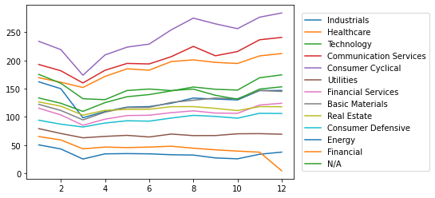

```python
for sector in sector_price_data.keys():
    month_averages = [0] * 12
    for company in sector_price_data[sector]:
        for month, i in enumerate(company):
            month_averages[month] += (company[month]/len(sector_price_data[sector]))
    plt.plot(([x + 1 for x in list(range(12))]), month_averages)

plt.legend(sector_price_data.keys(), loc="center right", borderaxespad=-17)
```

## Price Recovery

Now that we see that the main sell-off stages of this year began in February and March, we know that January will be the best indicator for pre-coronavirus sell off prices in each sector. We will average the price of each sector from January 1st and December 1st. Our goal here is to check the average recovery of each sector by comparing the pre-coronavirus sell off stock prices with the stock prices from the beginning of this month.

```python
pre_corona_sector_avg = {}
post_corona_sector_avg = {}

for s in sector_price_data.keys():
    pre_corona_sector_avg[s] = 0
    post_corona_sector_avg[s] = 0
    for x in sector_price_data[s]:
        pre_corona_sector_avg[s] += x[0]
        post_corona_sector_avg[s] += x[-1]
    pre_corona_sector_avg[s]  = pre_corona_sector_avg[s]/len(sector_price_data[s])
    post_corona_sector_avg[s] = post_corona_sector_avg[s]/len(sector_price_data[s])
```

[figure not shown]

```python
sectors = sector_price_data.keys()
g_sectors = []
g_values  = []

r_sectors = []
r_values  = []

recovery_dict = {}
for s in sectors:
    recovery = post_corona_sector_avg[s]/pre_corona_sector_avg[s]
    if recovery > 1.:
        g_sectors.append(recovery)
        g_values.append(s)
    else:
        r_sectors.append(recovery)
        r_values.append(s)
    recovery_dict[s] = recovery

plt.barh(g_values, g_sectors, color='g')
plt.barh(r_values, r_sectors, color='r')
plt.xlabel('Recovery Rate')
plt.show()
```

## Market Cap

In this next section we want to compare how market capitalization (the value of a given company based on the stock price), also known as market cap, correlates to the recovery rate we calculated above. We will take the average market cap of each sector for this analysis. The next plot compares the average market cap of each sector (x-axis) against their recovery over the past 12 months (y-axis)

Learn more about market cap here: https://www.investopedia.com/terms/m/marketcapitalization.asp

```python
market_cap_by_sector = {}

for row in stock_data.iloc:
    if row['Sector'] not in market_cap_by_sector.keys():
        market_cap_by_sector[row['Sector']] = 0
    mc = 0;
    if 'M' in row['Market Cap']:
        mc = float(row['Market Cap'].replace('M', '').replace(',', ''))
    elif 'B' in row['Market Cap']:
        mc = float(row['Market Cap'].replace('B', '').replace(',', ''))*1000
    elif 'T' in row['Market Cap']:
        mc = float(row['Market Cap'].replace('T', '').replace(',', ''))*1000000

    market_cap_by_sector[row['Sector']] += (mc/companies_per_sector[row['Sector']])

market_cap_by_sector
```

```
{'Industrials': 39346.62499999999,
 'Healthcare': 67245.078125,
 'Technology': 112673.42028985507,
 'Communication Services': 194054.8846153846,
 'Consumer Cyclical': 59194.609375,
 'Utilities': 30816.892857142862,
 'Financial Services': 58540.79411764708,
 'Basic Materials': 34486.90476190476,
 'Real Estate': 25755.6,
 'Consumer Defensive': 74100.08823529413,
 'Energy': 30921.92,
 'Financial': 718.932,
 'N/A': 44015.0}
```

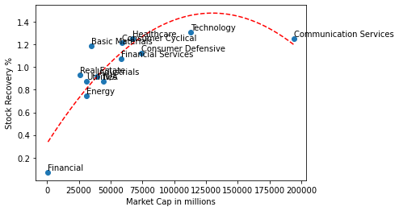

```python
import scipy.optimize as opt;
import numpy as np;
import math
x_data = [market_cap_by_sector[x] for x in market_cap_by_sector.keys()]
y_data = [recovery_dict[x] for x in recovery_dict.keys()]
plt.scatter(x_data, y_data)

for sector in market_cap_by_sector.keys():
    plt.text(market_cap_by_sector[sector], recovery_dict[sector] + .02, sector, )

plt.ylabel('Stock Recovery %')
plt.xlabel('Market Cap in millions')

def fit_func(x, a, b, c):
	return a * x + b * x**2 + c

popt, z= opt.curve_fit(fit_func, x_data, y_data)
a, b, c = popt
x_line = np.arange(min(x_data), max(x_data), 1)
y_line = fit_func(x_line, a, b, c)
plt.plot(x_line, y_line, '--', color='red')
```

From the fitted curve, it appears that the biggest impact on market recovery occurs when a company's market capitalization increases from approximately 25B to 100B. Above 100B, the market cap not longer appears to have a strong impact on rate of recovery. This means that, by our analysis, a company worth 50B is much more likely to have recovered from the market sell-off than a company worth 25B, likewise, a company worth 75B is much more likely to have recovered than a 50B company and so on. However, a 200B is not significantly more likely to have recovered when compared to a company worth 100B.

## Earnings Per Share

The next metric that we will consider is earnings per share (eps). Earnings per share is the amount of profit the company makes divided by the number of outstanding shares. EPS above 0 means that the company is profitable, and EPS below 0 means the company is losing money. By plotting the average EPS (x-axis) of each sector against each sector's average recovery rate (y-axis) we can see whether there is a correlation between the profitability of a company and their ability to recover from the coronavirus market sell-offs.

Learn more about EPS here: https://www.investopedia.com/terms/e/eps.asp

```python
eps_by_sector = {}

for row in stock_data.iloc:
    if row['Sector'] not in eps_by_sector.keys():
        eps_by_sector[row['Sector']] = 0

    eps = 0 if row['EPS'] == 'N/A' else float(row['EPS'])
    eps_by_sector[row['Sector']] += (eps/companies_per_sector[row['Sector']])

eps_by_sector
```

```
{'Industrials': 3.818888888888889,
 'Healthcare': 8.200625,
 'Technology': 3.839565217391305,
 'Communication Services': 6.047692307692306,
 'Consumer Cyclical': 7.701874999999999,
 'Utilities': 3.638928571428571,
 'Financial Services': 5.699705882352942,
 'Basic Materials': 3.1414285714285715,
 'Real Estate': 2.531,
 'Consumer Defensive': 4.097941176470589,
 'Energy': -7.888,
 'Financial': 1.275,
 'N/A': 0.0}
```

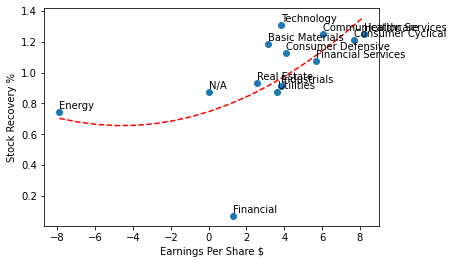

```python
x_data = [eps_by_sector[x] for x in eps_by_sector.keys()]
y_data = [recovery_dict[x] for x in recovery_dict.keys()]
plt.scatter(x_data, y_data)

for sector in eps_by_sector.keys():
    plt.text(eps_by_sector[sector], recovery_dict[sector] + .02, sector)

plt.ylabel('Stock Recovery %')
plt.xlabel('Earnings Per Share $')


def fit_func(x, a, b, c):
	return a * x + b * x**2 + c

popt, z= opt.curve_fit(fit_func, x_data, y_data)
a, b, c = popt
x_line = np.arange(min(x_data), max(x_data), 1)
y_line = fit_func(x_line, a, b, c)
plt.plot(x_line, y_line, '--', color='red')
```

## Price to Earnings (P/E) Ratio

The next metric that we will consider is the price to earnings ratio (p/e). Price to earnings is the price of a share of company stock divided by the earnings per share of that company. The higher the p/e ratio the more you have to pay for the profit of that company. For example, two companies may have the same earnings per share, but due to a variety of reasons one stock may have a higher price than the other: a company may be surrounded by excessive hype due to a good press release, one company may be faster growing that then other and that growth may be priced in and thus increase the p/e ratio, etc...

Below we will plot the average p/e ratio of each sector against the average recovery rate of the sector.

Learn more about P/E ratio here: https://www.investopedia.com/terms/p/price-earningsratio.asp

```python
pe_by_sector = {}

for row in stock_data.iloc:
    if row['Sector'] not in pe_by_sector.keys():
        pe_by_sector[row['Sector']] = 0

    pe = 0 if row['P/E Ratio'] == 'N/A' else float(row['P/E Ratio'])
    pe_by_sector[row['Sector']] += (pe/companies_per_sector[row['Sector']])

pe_by_sector
```

```
{'Industrials': 26.49722222222222,
 'Healthcare': 36.83093750000001,
 'Technology': 43.25130434782609,
 'Communication Services': 20.839230769230767,
 'Consumer Cyclical': 32.135312500000005,
 'Utilities': 19.27214285714286,
 'Financial Services': 21.409264705882357,
 'Basic Materials': 23.03809523809524,
 'Real Estate': 48.717000000000006,
 'Consumer Defensive': 27.924411764705884,
 'Energy': 25.937599999999996,
 'Financial': 3.62,
 'N/A': 13.61}
```

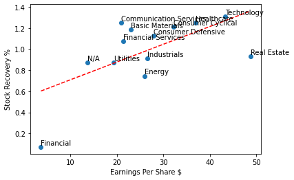

```python
x_data = [pe_by_sector[x] for x in pe_by_sector.keys()]
y_data = [recovery_dict[x] for x in recovery_dict.keys()]
plt.scatter(x_data, y_data)

for sector in pe_by_sector.keys():
    plt.text(pe_by_sector[sector], recovery_dict[sector] + .02, sector)

plt.ylabel('Stock Recovery %')
plt.xlabel('Earnings Per Share $')


def fit_func(x, a, b):
	return a * x + b

popt, z= opt.curve_fit(fit_func, x_data, y_data)
a, b = popt
x_line = np.arange(min(x_data), max(x_data), 1)
y_line = fit_func(x_line, a, b)
plt.plot(x_line, y_line, '--', color='red')
```

Due to the wide range of recovery for varying p/e ratios, a line appears to fit the data best. As opposed to other metrics, there appears to be a more subtle correlation between p/e ratio and recovery. It appears that there is a significant divide between the best performing stocks and the worst performing stocks. For the top performing stocks, p/e ratio may be a better indicator. This may be indicative of another factor not included in this plot.

Since there appeared to be two main clusters of data, we decided to split the data set to achieve a better line of best fit. The seperation was based on recovery rate. The plot below includes the sectores with and average stock price recovery rate above 0.95.

```python
x_data = [pe_by_sector[x] for x in pe_by_sector.keys() if recovery_dict[x] > .95]
y_data = [recovery_dict[x] for x in recovery_dict.keys() if recovery_dict[x] > .95]
plt.scatter(x_data, y_data)

for sector in pe_by_sector.keys():
    if recovery_dict[sector] > .95:
        plt.text(pe_by_sector[sector], recovery_dict[sector] + .02, sector)

plt.ylabel('Recovery Rate %')
plt.xlabel('P/E Ratio')

def fit_func(x, a, b):
    return a * x + b

popt, z = opt.curve_fit(fit_func, x_data, y_data)
a, b    = popt
x_line  = np.arange(min(x_data), max(x_data), 1)
y_line  = fit_func(x_line, a, b)
plt.plot(x_line, y_line, '--', color='red')
```

[output not shown]

```python
x_data = [pe_by_sector[x] for x in pe_by_sector.keys() if recovery_dict[x] <= .95]
y_data = [recovery_dict[x] for x in recovery_dict.keys() if recovery_dict[x] <= .95]
plt.scatter(x_data, y_data)

for sector in pe_by_sector.keys():
    if recovery_dict[sector] <= .95:
        plt.text(pe_by_sector[sector], recovery_dict[sector] + .02, sector)

plt.ylabel('Recovery Rate %')
plt.xlabel('P/E Ratio')

def fit_func(x, a, b):
    return a * x + b

popt, z= opt.curve_fit(fit_func, x_data, y_data)
a, b = popt
x_line = np.arange(min(x_data), max(x_data), 1)
y_line = fit_func(x_line, a, b)
plt.plot(x_line, y_line, '--', color='red')
```

[output not shown]

# Analysis: Within Sectors

Since we will be performing the above analyses within each sector now, we are going to choose five sectors of high interest to refrain from saturating the project with graphs and numbers. The five sectors we will be looking at in more depth will be health care, technology, financial services, real estate, and energy.

## Restructuring the Data

```python
#split the stock data into five separate dataframes based on our sectors of interest for easier access

#create empty dataframes
health_care_data = pd.DataFrame()
technology_data = pd.DataFrame()
financial_services_data = pd.DataFrame()
real_estate_data = pd.DataFrame()
energy_data = pd.DataFrame()

#populate dataframes
for index, row in stock_data.iterrows():
    if row['Sector'] == 'Healthcare':
        health_care_data = health_care_data.append({'Ticker': row['Ticker'], 'Name': row['Name'], 'Current Price': row['Current Price'],
                               'P/E Ratio': row['P/E Ratio'], 'Market Cap': row['Market Cap'], 'Volume': row['Volume'],
                               'EPS': row['EPS'], 'Historical Prices': row['Historical Prices'], 'Sector': row['Sector']},
                                ignore_index = True)
    elif row['Sector'] == 'Technology':
        technology_data = technology_data.append({'Ticker': row['Ticker'], 'Name': row['Name'], 'Current Price': row['Current Price'],
                               'P/E Ratio': row['P/E Ratio'], 'Market Cap': row['Market Cap'], 'Volume': row['Volume'],
                               'EPS': row['EPS'], 'Historical Prices': row['Historical Prices'], 'Sector': row['Sector']},
                                ignore_index = True)
    elif row['Sector'] == 'Financial Services':
        financial_services_data = financial_services_data.append({'Ticker': row['Ticker'], 'Name': row['Name'], 'Current Price': row['Current Price'],
                               'P/E Ratio': row['P/E Ratio'], 'Market Cap': row['Market Cap'], 'Volume': row['Volume'],
                               'EPS': row['EPS'], 'Historical Prices': row['Historical Prices'], 'Sector': row['Sector']},
                                ignore_index = True)
    elif row['Sector'] == 'Real Estate':
        real_estate_data = real_estate_data.append({'Ticker': row['Ticker'], 'Name': row['Name'], 'Current Price': row['Current Price'],
                               'P/E Ratio': row['P/E Ratio'], 'Market Cap': row['Market Cap'], 'Volume': row['Volume'],
                               'EPS': row['EPS'], 'Historical Prices': row['Historical Prices'], 'Sector': row['Sector']},
                                ignore_index = True)
    elif row['Sector'] == 'Energy':
        energy_data = energy_data.append({'Ticker': row['Ticker'], 'Name': row['Name'], 'Current Price': row['Current Price'],
                               'P/E Ratio': row['P/E Ratio'], 'Market Cap': row['Market Cap'], 'Volume': row['Volume'],
                               'EPS': row['EPS'], 'Historical Prices': row['Historical Prices'], 'Sector': row['Sector']},
                                ignore_index = True)

#reorder dataframe columns
health_care_data = health_care_data[['Ticker', 'Name', 'Current Price', 'P/E Ratio', 'Market Cap', 'Volume', 'EPS',
                                  'Historical Prices', 'Sector']]

technology_data = technology_data[['Ticker', 'Name', 'Current Price', 'P/E Ratio', 'Market Cap', 'Volume', 'EPS',
                                  'Historical Prices', 'Sector']]

financial_services_data = financial_services_data[['Ticker', 'Name', 'Current Price', 'P/E Ratio', 'Market Cap', 'Volume', 'EPS',
                                  'Historical Prices', 'Sector']]

real_estate_data = real_estate_data[['Ticker', 'Name', 'Current Price', 'P/E Ratio', 'Market Cap', 'Volume', 'EPS',
                                  'Historical Prices', 'Sector']]

energy_data = energy_data[['Ticker', 'Name', 'Current Price', 'P/E Ratio', 'Market Cap', 'Volume', 'EPS',
                                  'Historical Prices', 'Sector']]

#compute price recovery for each company and add to dataframe - we will be using price recovery as a ranking
#metric momentarily
nan = math.nan
price_recovery1 = []
price_recovery2 = []
price_recovery3 = []
price_recovery4 = []
price_recovery5 = []

for index, row in health_care_data.iterrows():
    #clean strings with commas for float conversion
    dec = row['Historical Prices'][-1].replace(',', '')
    jan = row['Historical Prices'][0].replace(',', '')

    #compute price recovery
    item = float(dec)/float(jan)
    price_recovery1.append(item)

for index, row in technology_data.iterrows():
    #clean strings with commas for float conversion
    dec = row['Historical Prices'][-1].replace(',', '')
    jan = row['Historical Prices'][0].replace(',', '')

    #compute price recovery
    item = float(dec)/float(jan)
    price_recovery2.append(item)

for index, row in financial_services_data.iterrows():
    #clean strings with commas for float conversion
    if len(row['Historical Prices']) != 0:
        dec = row['Historical Prices'][-1].replace(',', '')
        jan = row['Historical Prices'][0].replace(',', '')

        #compute price recovery
        item = float(dec)/float(jan)
        price_recovery3.append(item)
    elif len(row['Historical Prices']) == 0:

        item = nan
        price_recovery3.append(item)

for index, row in real_estate_data.iterrows():
    #clean strings with commas for float conversion
    dec = row['Historical Prices'][-1].replace(',', '')
    jan = row['Historical Prices'][0].replace(',', '')

    #compute price recovery
    item = float(dec)/float(jan)
    price_recovery4.append(item)

for index, row in energy_data.iterrows():
    #clean strings with commas for float conversion
    dec = row['Historical Prices'][-1].replace(',', '')
    jan = row['Historical Prices'][0].replace(',', '')

    #compute price recovery
    item = float(dec)/float(jan)
    price_recovery5.append(item)

#add to dataframe
health_care_data['Price Recovery'] = price_recovery1
technology_data['Price Recovery'] = price_recovery2
financial_services_data['Price Recovery'] = price_recovery3
real_estate_data['Price Recovery'] = price_recovery4
energy_data['Price Recovery'] = price_recovery5
```

Now, using price recovery as a ranking metric we will analyze the top and bottom 5 companies in each sector

```python
#restructure dataframes to only consist of top and bottom 5 companies

#sort dataframes based on price recovery
health_care_data = health_care_data.sort_values('Price Recovery')
technology_data = technology_data.sort_values('Price Recovery')
financial_services_data = financial_services_data.sort_values('Price Recovery')
real_estate_data = real_estate_data.sort_values('Price Recovery')
energy_data = energy_data.sort_values('Price Recovery')

#create new dataframes
hc_data = pd.DataFrame()
t_data = pd.DataFrame()
fs_data_temp = pd.DataFrame()
fs_data = pd.DataFrame()
re_data = pd.DataFrame()
e_data = pd.DataFrame()

#add bottom and top 5 companies
hc_data = hc_data.append(health_care_data.head(), ignore_index = True)
hc_data = hc_data.append(health_care_data.tail(), ignore_index = True)

t_data = t_data.append(technology_data.head(), ignore_index = True)
t_data = t_data.append(technology_data.tail(), ignore_index = True)

fs_data_temp = fs_data_temp.append(financial_services_data.head(), ignore_index = True)
fs_data_temp = fs_data_temp.append(financial_services_data.tail(6), ignore_index = True)
fs_data = fs_data.append(fs_data_temp.head(10), ignore_index = True)

re_data = re_data.append(real_estate_data.head(), ignore_index = True)
re_data = re_data.append(real_estate_data.tail(), ignore_index = True)

e_data = e_data.append(energy_data.head(), ignore_index = True)
e_data = e_data.append(energy_data.tail(), ignore_index = True)

#clean market cap data for later use
for index, row in hc_data.iterrows():
    if 'M' in row['Market Cap']:
        hc_data['Market Cap'][index] = row['Market Cap'].replace('M', '')
    elif 'B' in row['Market Cap']:
        hc_data['Market Cap'][index] = row['Market Cap'].replace('B', '')
    elif 'T' in row['Market Cap']:
        hc_data['Market Cap'][index] = row['Market Cap'].replace('T', '')

for index, row in t_data.iterrows():
    if 'M' in row['Market Cap']:
        t_data['Market Cap'][index] = row['Market Cap'].replace('M', '')
    elif 'B' in row['Market Cap']:
        t_data['Market Cap'][index] = row['Market Cap'].replace('B', '')
    elif 'T' in row['Market Cap']:
        t_data['Market Cap'][index] = row['Market Cap'].replace('T', '')

for index, row in fs_data.iterrows():
    if 'M' in row['Market Cap']:
        fs_data['Market Cap'][index] = row['Market Cap'].replace('M', '')
    elif 'B' in row['Market Cap']:
        fs_data['Market Cap'][index] = row['Market Cap'].replace('B', '')
    elif 'T' in row['Market Cap']:
        fs_data['Market Cap'][index] = row['Market Cap'].replace('T', '')

for index, row in re_data.iterrows():
    if 'M' in row['Market Cap']:
        re_data['Market Cap'][index] = row['Market Cap'].replace('M', '')
    elif 'B' in row['Market Cap']:
        re_data['Market Cap'][index] = row['Market Cap'].replace('B', '')
    elif 'T' in row['Market Cap']:
        re_data['Market Cap'][index] = row['Market Cap'].replace('T', '')

for index, row in e_data.iterrows():
    if 'M' in row['Market Cap']:
        e_data['Market Cap'][index] = row['Market Cap'].replace('M', '')
    elif 'B' in row['Market Cap']:
        e_data['Market Cap'][index] = row['Market Cap'].replace('B', '')
    elif 'T' in row['Market Cap']:
        e_data['Market Cap'][index] = row['Market Cap'].replace('T', '')
```

## Healthcare - Price Visualization

The plot below shows the price change for the top and bottom 5 companies in the healthcare sector from month to month over the course of 2020

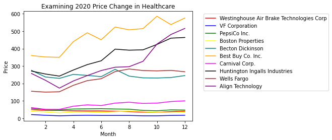

```python
#store coordinates to plot
x = [1,2,3,4,5,6,7,8,9,10,11,12]
hc_y = []

# plt.plot(x, y1, "-b", label="sine")
# plt.plot(x, y2, "-r", label="cosine")

#convert y-values to ints for easier use
for i in range(12):
    item = int(float(hc_data['Historical Prices'][0][i]))
    hc_y.append(item)

plt.plot(x,hc_y, color="red", label=hc_data['Name'][0])

hc_y = []

#convert y-values to ints for easier use
for i in range(12):
    item = int(float(hc_data['Historical Prices'][1][i]))
    hc_y.append(item)

plt.plot(x,hc_y, color="blue", label=hc_data['Name'][1])

hc_y = []

#convert y-values to ints for easier use
for i in range(12):
    item = int(float(hc_data['Historical Prices'][2][i]))
    hc_y.append(item)

plt.plot(x,hc_y, color="green", label=hc_data['Name'][2])

hc_y = []

#convert y-values to ints for easier use
for i in range(12):
    item = int(float(hc_data['Historical Prices'][3][i]))
    hc_y.append(item)

plt.plot(x,hc_y, color="yellow", label=hc_data['Name'][3])

hc_y = []

#convert y-values to ints for easier use
for i in range(12):
    item = int(float(hc_data['Historical Prices'][4][i]))
    hc_y.append(item)

plt.plot(x,hc_y, color="teal", label=hc_data['Name'][4])

hc_y = []

#convert y-values to ints for easier use
for i in range(12):
    item = int(float(hc_data['Historical Prices'][5][i]))
    hc_y.append(item)

plt.plot(x,hc_y, color="orange", label=hc_data['Name'][5])

hc_y = []

#convert y-values to ints for easier use
for i in range(12):
    item = int(float(hc_data['Historical Prices'][6][i]))
    hc_y.append(item)

plt.plot(x,hc_y, color="magenta", label=hc_data['Name'][6])

hc_y = []

#convert y-values to ints for easier use
for i in range(12):
    item = int(float(hc_data['Historical Prices'][7][i]))
    hc_y.append(item)

plt.plot(x,hc_y, color="black", label=hc_data['Name'][7])

hc_y = []

#convert y-values to ints for easier use
for i in range(12):
    item = int(float(hc_data['Historical Prices'][8][i]))
    hc_y.append(item)

plt.plot(x,hc_y, color="brown", label=hc_data['Name'][8])

hc_y = []

#convert y-values to ints for easier use
for i in range(12):
    item = int(float(hc_data['Historical Prices'][9][i]))
    hc_y.append(item)

plt.plot(x,hc_y, color="purple", label=hc_data['Name'][9])

#label axes and title plot
plt.xlabel("Month")
plt.ylabel("Price")
plt.title("Examining 2020 Price Change in Healthcare")

#add key
plt.legend(bbox_to_anchor=(1.05, 1), loc="upper left")
```

## Healthcare - Price Recovery

Next, we will examine the stock price recovery of these 10 companies by plotting the metric that results from dividing a company's December stock price by its January stock price. Using this pre and post coronavirus data in this way will give us company data on a scale relative to the company's original price. This will allow us to see which companies recovered best from the cornovirus market sell offs in the healthcare sector. Keep in mind that the 10 companies that were chosen to be examined within the sector were chosen based on this metric - we included the 5 best recovered companies and the 5 worst recovered companies.

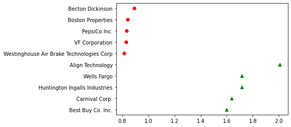

```python
#green companies had values greater than 1 - indicating they are doing better at the end of 2020 compared to the
#beginning
g_companies = []
g_values  = []

#red companies had values less than 1 - indicating they are doing worse at the end of 2020 compared to the
#beginning
r_companies = []
r_values  = []

#place values in correct category
for index, row in hc_data.iterrows():
    if row['Price Recovery'] > 1.:
        g_companies.append(row['Name'])
        g_values.append(row['Price Recovery'])
    else:
        r_companies.append(row['Name'])
        r_values.append(row['Price Recovery'])


#populate plot
plt.scatter(g_values, g_companies, marker='^', color='g')
plt.scatter(r_values, r_companies, marker='o', color='r')

#display plot
plt.show()
```

## Healthcare - Market Cap

The next plot compares the price recovery of each of these 10 companies against the market cap of that company

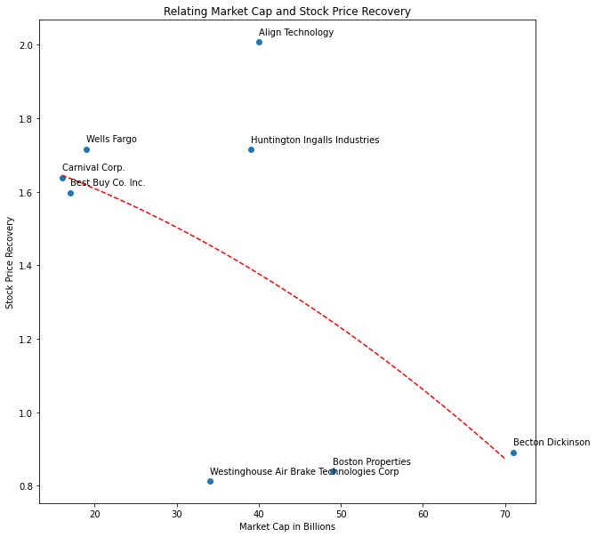

```python
#manipulate market cap data for easier plotting
for index, row in hc_data.iterrows():
         hc_data['Market Cap'][index] = int(float(row['Market Cap']))

#set plot size
plt.figure(figsize=(10,10))

#plot data
plt.scatter(hc_data['Market Cap'], hc_data['Price Recovery'])

#label points
for index, row in hc_data.iterrows():
    plt.text(row['Market Cap'], row['Price Recovery'] + 0.02, row['Name'])

#label axes and title plot
plt.ylabel('Stock Price Recovery')
plt.xlabel('Market Cap in Billions')
plt.title("Relating Market Cap and Stock Price Recovery")

def fit_func(x, a, b, c):
	return a * x + b * x**2 + c

popt, z= opt.curve_fit(fit_func, hc_data['Market Cap'], hc_data['Price Recovery'])
a, b, c = popt
x_line = np.arange(min(hc_data['Market Cap']), max(hc_data['Market Cap']), 1)
y_line = fit_func(x_line, a, b, c)
plt.plot(x_line, y_line, '--', color='red')
```

## Healthcare - Earnings Per Share

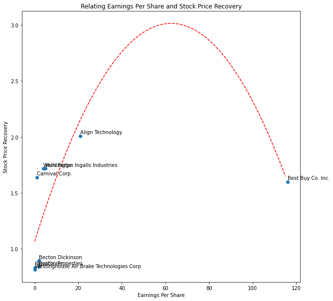

```python
#Note that there is not enough data able for us to be able to perform this computation/analysis for
#every company in our dataframe - we will do it for those that we can

#manipulate earnings per share data for easier plotting
for index, row in hc_data.iterrows():
    if row['EPS'] != 'N/A':
        hc_data['EPS'][index] = int(float(row['EPS']))
    else:
        hc_data = hc_data.drop(index)

#set plot size
plt.figure(figsize=(10,10))

#plot data
plt.scatter(hc_data['EPS'], hc_data['Price Recovery'])

#label points
for index, row in hc_data.iterrows():
    plt.text(row['EPS'], row['Price Recovery'] + 0.02, row['Name'])

#label axes and title plot
plt.ylabel('Stock Price Recovery')
plt.xlabel('Earnings Per Share')
plt.title("Relating Earnings Per Share and Stock Price Recovery")

def fit_func(x, a, b, c):
	return a * x + b * x**2 + c

popt, z= opt.curve_fit(fit_func, hc_data['EPS'], hc_data['Price Recovery'])
a, b, c = popt
x_line = np.arange(min(hc_data['EPS']), max(hc_data['EPS']), 1)
y_line = fit_func(x_line, a, b, c)
plt.plot(x_line, y_line, '--', color='red')
```

## Healthcare - P/E Ratio

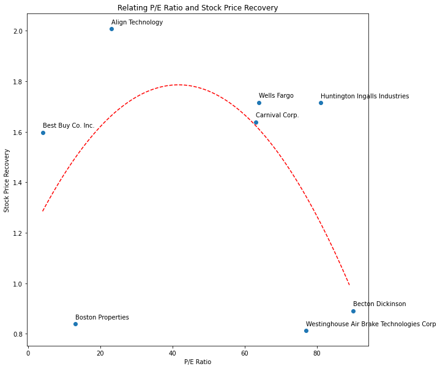

```python
#Note that there is not enough data able for us to be able to perform this computation/analysis for
#every company in our dataframe - we will do it for those that we can

#manipulate earnings per share data for easier plotting
for index, row in hc_data.iterrows():
    if row['P/E Ratio'] != 'N/A':
        hc_data['P/E Ratio'][index] = int(float(row['P/E Ratio']))
    else:
        hc_data = hc_data.drop(index)

#set plot size
plt.figure(figsize=(10,10))

#plot data
plt.scatter(hc_data['P/E Ratio'], hc_data['Price Recovery'])

#label points
for index, row in hc_data.iterrows():
    plt.text(row['P/E Ratio'], row['Price Recovery'] + 0.02, row['Name'])

#label axes and title plot
plt.ylabel('Stock Price Recovery')
plt.xlabel('P/E Ratio')
plt.title("Relating P/E Ratio and Stock Price Recovery")

def fit_func(x, a, b, c):
	return a * x + b * x**2 + c

popt, z= opt.curve_fit(fit_func, hc_data['P/E Ratio'], hc_data['Price Recovery'])
a, b, c = popt
x_line = np.arange(min(hc_data['P/E Ratio']), max(hc_data['P/E Ratio']), 1)
y_line = fit_func(x_line, a, b, c)
plt.plot(x_line, y_line, '--', color='red')
```

## Technology - Price Visualization

The plot below shows the price change for the top and bottom 5 companies in the technology sector from month to month over the course of 2020

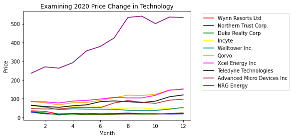

```python
#store coordinates to plot
x = [1,2,3,4,5,6,7,8,9,10,11,12]
t_y = []

#convert y-values to ints for easier use
for i in range(12):
    item = int(float(t_data['Historical Prices'][0][i]))
    t_y.append(item)

plt.plot(x,t_y, color="red", label=t_data['Name'][0])

t_y = []

#convert y-values to ints for easier use
for i in range(12):
    item = int(float(t_data['Historical Prices'][1][i]))
    t_y.append(item)

plt.plot(x,t_y, color="blue", label=t_data['Name'][1])

t_y = []

#convert y-values to ints for easier use
for i in range(12):
    item = int(float(t_data['Historical Prices'][2][i]))
    t_y.append(item)

plt.plot(x,t_y, color="green", label=t_data['Name'][2])

t_y = []

#convert y-values to ints for easier use
for i in range(12):
    item = int(float(t_data['Historical Prices'][3][i]))
    t_y.append(item)

plt.plot(x,t_y, color="yellow", label=t_data['Name'][3])

t_y = []

#convert y-values to ints for easier use
for i in range(12):
    item = int(float(t_data['Historical Prices'][4][i]))
    t_y.append(item)

plt.plot(x,t_y, color="teal", label=t_data['Name'][4])

t_y = []

#convert y-values to ints for easier use
for i in range(12):
    item = int(float(t_data['Historical Prices'][5][i]))
    t_y.append(item)

plt.plot(x,t_y, color="orange", label=t_data['Name'][5])

t_y = []

#convert y-values to ints for easier use
for i in range(12):
    item = int(float(t_data['Historical Prices'][6][i]))
    t_y.append(item)

plt.plot(x,t_y, color="magenta", label=t_data['Name'][6])

t_y = []

#convert y-values to ints for easier use
for i in range(12):
    item = int(float(t_data['Historical Prices'][7][i]))
    t_y.append(item)

plt.plot(x,t_y, color="black", label=t_data['Name'][7])

t_y = []

#convert y-values to ints for easier use
for i in range(12):
    item = int(float(t_data['Historical Prices'][8][i]))
    t_y.append(item)

plt.plot(x,t_y, color="brown", label=t_data['Name'][8])

t_y = []

#convert y-values to ints for easier use
for i in range(12):
    item = int(float(t_data['Historical Prices'][9][i]))
    t_y.append(item)

plt.plot(x,t_y, color="purple", label=t_data['Name'][9])

#label axes and title plot
plt.xlabel("Month")
plt.ylabel("Price")
plt.title("Examining 2020 Price Change in Technology")

#add key
plt.legend(bbox_to_anchor=(1.05, 1), loc="upper left")
```

## Technology - Price Recovery

Next, we will examine the stock price recovery of these 10 companies by plotting the metric that results from dividing a company's December stock price by its January stock price. Using this pre and post coronavirus data in this way will give us company data on a scale relative to the company's original price. This will allow us to see which companies recovered best from the cornovirus market sell offs in the technology sector. Keep in mind that the 10 companies that were chosen to be examined within the sector were chosen based on this metric - we included the 5 best recovered companies and the 5 worst recovered companies.

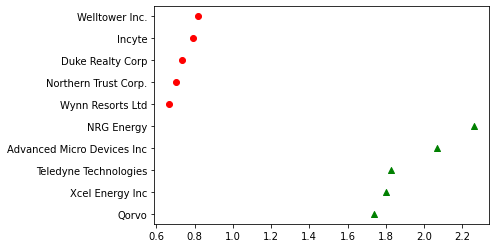

```python
#green companies had values greater than 1 - indicating they are doing better at the end of 2020 compared to the
#beginning
g_companies = []
g_values  = []

#red companies had values less than 1 - indicating they are doing worse at the end of 2020 compared to the
#beginning
r_companies = []
r_values  = []

#place values in correct category
for index, row in t_data.iterrows():
    if row['Price Recovery'] > 1.:
        g_companies.append(row['Name'])
        g_values.append(row['Price Recovery'])
    else:
        r_companies.append(row['Name'])
        r_values.append(row['Price Recovery'])


#populate plot
plt.scatter(g_values, g_companies, marker='^', color='g')
plt.scatter(r_values, r_companies, marker='o', color='r')

#display plot
plt.show()
```

## Technology - Market Cap

The next plot compares the price recovery of each of these 10 companies against the market cap of that company

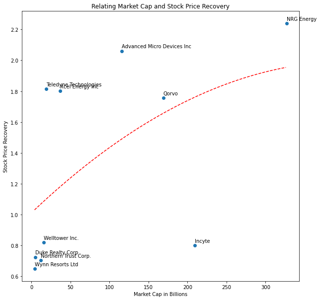

```python
#manipulate market cap data for easier plotting
for index, row in t_data.iterrows():
         t_data['Market Cap'][index] = int(float(row['Market Cap']))

#set plot size
plt.figure(figsize=(10,10))

#plot data
plt.scatter(t_data['Market Cap'], t_data['Price Recovery'])

#label points
for index, row in t_data.iterrows():
    plt.text(row['Market Cap'], row['Price Recovery'] + 0.02, row['Name'])

#label axes and title plot
plt.ylabel('Stock Price Recovery')
plt.xlabel('Market Cap in Billions')
plt.title("Relating Market Cap and Stock Price Recovery")

def fit_func(x, a, b, c):
	return a * x + b * x**2 + c

popt, z= opt.curve_fit(fit_func, t_data['Market Cap'], t_data['Price Recovery'])
a, b, c = popt
x_line = np.arange(min(t_data['Market Cap']), max(t_data['Market Cap']), 1)
y_line = fit_func(x_line, a, b, c)
plt.plot(x_line, y_line, '--', color='red')
```

## Technology - Earnings Per Share

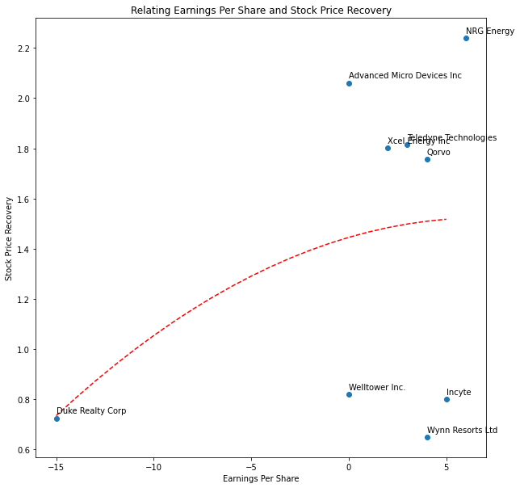

```python
#Note that there is not enough data able for us to be able to perform this computation/analysis for
#every company in our dataframe - we will do it for those that we can

#manipulate earnings per share data for easier plotting
for index, row in t_data.iterrows():
    if row['EPS'] != 'N/A':
        t_data['EPS'][index] = int(float(row['EPS']))
    else:
        t_data = t_data.drop(index)

#set plot size
plt.figure(figsize=(10,10))

#plot data
plt.scatter(t_data['EPS'], t_data['Price Recovery'])

#label points
for index, row in t_data.iterrows():
    plt.text(row['EPS'], row['Price Recovery'] + 0.02, row['Name'])

#label axes and title plot
plt.ylabel('Stock Price Recovery')
plt.xlabel('Earnings Per Share')
plt.title("Relating Earnings Per Share and Stock Price Recovery")

def fit_func(x, a, b, c):
	return a * x + b * x**2 + c

popt, z= opt.curve_fit(fit_func, t_data['EPS'], t_data['Price Recovery'])
a, b, c = popt
x_line = np.arange(min(t_data['EPS']), max(t_data['EPS']), 1)
y_line = fit_func(x_line, a, b, c)
plt.plot(x_line, y_line, '--', color='red')
```

## Technology - P/E Ratio

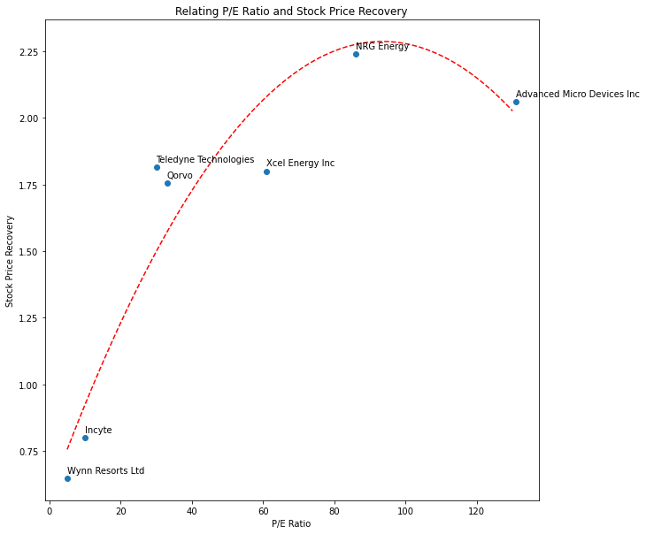

```python
#Note that there is not enough data able for us to be able to perform this computation/analysis for
#every company in our dataframe - we will do it for those that we can

#manipulate earnings per share data for easier plotting
for index, row in t_data.iterrows():
    if row['P/E Ratio'] != 'N/A':
        t_data['P/E Ratio'][index] = int(float(row['P/E Ratio']))
    else:
        t_data = t_data.drop(index)

#set plot size
plt.figure(figsize=(10,10))

#plot data
plt.scatter(t_data['P/E Ratio'], t_data['Price Recovery'])

#label points
for index, row in t_data.iterrows():
    plt.text(row['P/E Ratio'], row['Price Recovery'] + 0.02, row['Name'])

#label axes and title plot
plt.ylabel('Stock Price Recovery')
plt.xlabel('P/E Ratio')
plt.title("Relating P/E Ratio and Stock Price Recovery")

def fit_func(x, a, b, c):
	return a * x + b * x**2 + c

popt, z= opt.curve_fit(fit_func, t_data['P/E Ratio'], t_data['Price Recovery'])
a, b, c = popt
x_line = np.arange(min(t_data['P/E Ratio']), max(t_data['P/E Ratio']), 1)
y_line = fit_func(x_line, a, b, c)
plt.plot(x_line, y_line, '--', color='red')
```

## Financial Services - Price Visualization

The plot below shows the price change for the top and bottom 5 companies in the financial services sector from month to month over the course of 2020

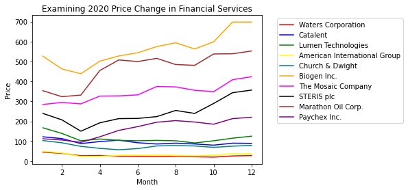

```python
#store coordinates to plot
x = [1,2,3,4,5,6,7,8,9,10,11,12]
fs_y = []

#convert y-values to ints for easier use
for i in range(12):
    item = int(float(fs_data['Historical Prices'][0][i]))
    fs_y.append(item)

plt.plot(x,fs_y, color="red", label=fs_data['Name'][0])

fs_y = []

#convert y-values to ints for easier use
for i in range(12):
    item = int(float(fs_data['Historical Prices'][1][i]))
    fs_y.append(item)

plt.plot(x,fs_y, color="blue", label=fs_data['Name'][1])

fs_y = []

#convert y-values to ints for easier use
for i in range(12):
    item = int(float(fs_data['Historical Prices'][2][i]))
    fs_y.append(item)

plt.plot(x,fs_y, color="green", label=fs_data['Name'][2])

fs_y = []

#convert y-values to ints for easier use
for i in range(12):
    item = int(float(fs_data['Historical Prices'][3][i]))
    fs_y.append(item)

plt.plot(x,fs_y, color="yellow", label=fs_data['Name'][3])

fs_y = []

#convert y-values to ints for easier use
for i in range(12):
    item = int(float(fs_data['Historical Prices'][4][i]))
    fs_y.append(item)

plt.plot(x,fs_y, color="teal", label=fs_data['Name'][4])

fs_y = []

#convert y-values to ints for easier use
for i in range(12):
    item = int(float(fs_data['Historical Prices'][5][i]))
    fs_y.append(item)

plt.plot(x,fs_y, color="orange", label=fs_data['Name'][5])

fs_y = []

#convert y-values to ints for easier use
for i in range(12):
    item = int(float(fs_data['Historical Prices'][6][i]))
    fs_y.append(item)

plt.plot(x,fs_y, color="magenta", label=fs_data['Name'][6])

fs_y = []

#convert y-values to ints for easier use
for i in range(12):
    item = int(float(fs_data['Historical Prices'][7][i]))
    fs_y.append(item)

plt.plot(x,fs_y, color="black", label=fs_data['Name'][7])

fs_y = []

#convert y-values to ints for easier use
for i in range(12):
    item = int(float(fs_data['Historical Prices'][8][i]))
    fs_y.append(item)

plt.plot(x,fs_y, color="brown", label=fs_data['Name'][8])

fs_y = []

#convert y-values to ints for easier use
for i in range(12):
    item = int(float(fs_data['Historical Prices'][9][i]))
    fs_y.append(item)

plt.plot(x,fs_y, color="purple", label=fs_data['Name'][9])

#label axes and title plot
plt.xlabel("Month")
plt.ylabel("Price")
plt.title("Examining 2020 Price Change in Financial Services")

#add key
plt.legend(bbox_to_anchor=(1.05, 1), loc="upper left")
```

## Financial Services - Price Recovery

Next, we will examine the stock price recovery of these 10 companies by plotting the metric that results from dividing a company's December stock price by its January stock price. Using this pre and post coronavirus data in this way will give us company data on a scale relative to the company's original price. This will allow us to see which companies recovered best from the cornovirus market sell offs in the financial services sector. Keep in mind that the 10 companies that were chosen to be examined within the sector were chosen based on this metric - we included the 5 best recovered companies and the 5 worst recovered companies.

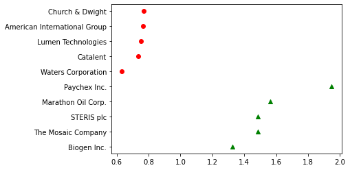

```python
#green companies had values greater than 1 - indicating they are doing better at the end of 2020 compared to the
#beginning
g_companies = []
g_values  = []

#red companies had values less than 1 - indicating they are doing worse at the end of 2020 compared to the
#beginning
r_companies = []
r_values  = []

#place values in correct category
for index, row in fs_data.iterrows():
    if row['Price Recovery'] > 1.:
        g_companies.append(row['Name'])
        g_values.append(row['Price Recovery'])
    else:
        r_companies.append(row['Name'])
        r_values.append(row['Price Recovery'])


#populate plot
plt.scatter(g_values, g_companies, marker='^', color='g')
plt.scatter(r_values, r_companies, marker='o', color='r')

#display plot
plt.show()
```

## Financial Services - Market Cap

The next plot compares the price recovery of each of these 10 companies against the market cap of that company

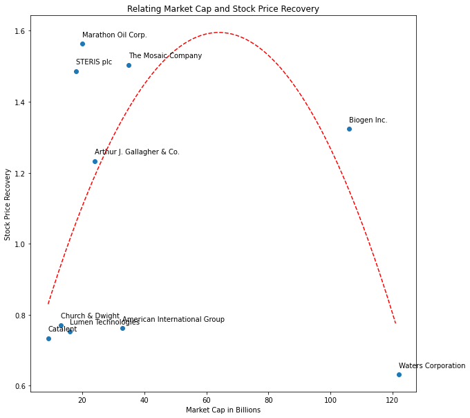

```python
#manipulate market cap data for easier plotting
for index, row in fs_data.iterrows():
         fs_data['Market Cap'][index] = int(float(row['Market Cap']))

#set plot size
plt.figure(figsize=(10,10))

#plot data
plt.scatter(fs_data['Market Cap'], fs_data['Price Recovery'])

#label points
for index, row in fs_data.iterrows():
    plt.text(row['Market Cap'], row['Price Recovery'] + 0.02, row['Name'])

#label axes and title plot
plt.ylabel('Stock Price Recovery')
plt.xlabel('Market Cap in Billions')
plt.title("Relating Market Cap and Stock Price Recovery")

def fit_func(x, a, b, c):
	return a * x + b * x**2 + c

popt, z= opt.curve_fit(fit_func, fs_data['Market Cap'], fs_data['Price Recovery'])
a, b, c = popt
x_line = np.arange(min(fs_data['Market Cap']), max(fs_data['Market Cap']), 1)
y_line = fit_func(x_line, a, b, c)
plt.plot(x_line, y_line, '--', color='red')
```

## Financial Services - Earnings Per Share

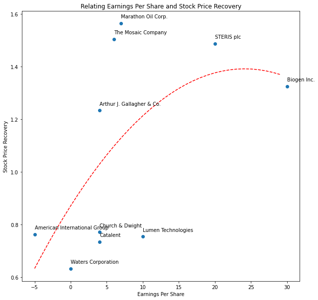

```python
#Note that there is not enough data able for us to be able to perform this computation/analysis for
#every company in our dataframe - we will do it for those that we can

#manipulate earnings per share data for easier plotting
for index, row in fs_data.iterrows():
    if row['EPS'] != 'N/A':
        fs_data['EPS'][index] = int(float(row['EPS']))
    else:
        fs_data = fs_data.drop(index)

#set plot size
plt.figure(figsize=(10,10))

#plot data
plt.scatter(fs_data['EPS'], fs_data['Price Recovery'])

#label points
for index, row in fs_data.iterrows():
    plt.text(row['EPS'], row['Price Recovery'] + 0.02, row['Name'])

#label axes and title plot
plt.ylabel('Stock Price Recovery')
plt.xlabel('Earnings Per Share')
plt.title("Relating Earnings Per Share and Stock Price Recovery")

def fit_func(x, a, b, c):
	return a * x + b * x**2 + c

popt, z= opt.curve_fit(fit_func, fs_data['EPS'], fs_data['Price Recovery'])
a, b, c = popt
x_line = np.arange(min(fs_data['EPS']), max(fs_data['EPS']), 1)
y_line = fit_func(x_line, a, b, c)
plt.plot(x_line, y_line, '--', color='red')
```

## Financial Services - P/E Ratio

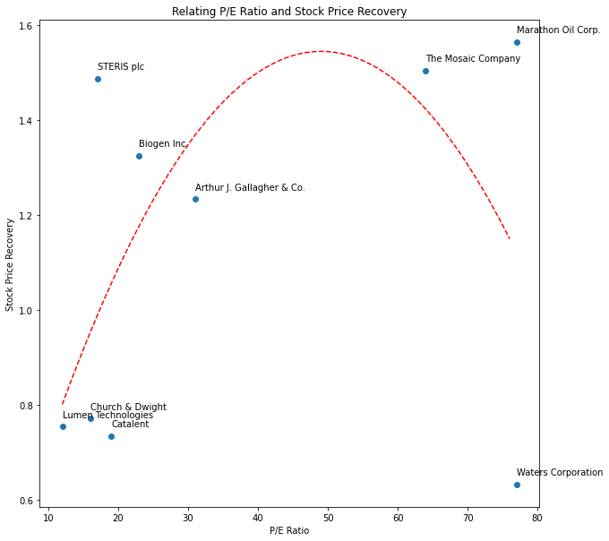

```python
#Note that there is not enough data able for us to be able to perform this computation/analysis for
#every company in our dataframe - we will do it for those that we can

#manipulate earnings per share data for easier plotting
for index, row in fs_data.iterrows():
    if row['P/E Ratio'] != 'N/A':
        fs_data['P/E Ratio'][index] = int(float(row['P/E Ratio']))
    else:
        fs_data = fs_data.drop(index)

#set plot size
plt.figure(figsize=(10,10))

#plot data
plt.scatter(fs_data['P/E Ratio'], fs_data['Price Recovery'])

#label points
for index, row in fs_data.iterrows():
    plt.text(row['P/E Ratio'], row['Price Recovery'] + 0.02, row['Name'])

#label axes and title plot
plt.ylabel('Stock Price Recovery')
plt.xlabel('P/E Ratio')
plt.title("Relating P/E Ratio and Stock Price Recovery")

def fit_func(x, a, b, c):
	return a * x + b * x**2 + c

popt, z= opt.curve_fit(fit_func, fs_data['P/E Ratio'], fs_data['Price Recovery'])
a, b, c = popt
x_line = np.arange(min(fs_data['P/E Ratio']), max(fs_data['P/E Ratio']), 1)
y_line = fit_func(x_line, a, b, c)
plt.plot(x_line, y_line, '--', color='red')
```

## Real Estate - Price Visualization

The plot below shows the price change for the top and bottom 5 companies in the real estate sector from month to month over the course of 2020

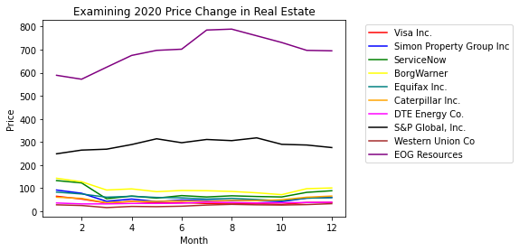

```python
#store coordinates to plot
x = [1,2,3,4,5,6,7,8,9,10,11,12]
re_y = []

#convert y-values to ints for easier use
for i in range(12):
    item = int(float(re_data['Historical Prices'][0][i]))
    re_y.append(item)

plt.plot(x,re_y, color="red", label=re_data['Name'][0])

re_y = []

#convert y-values to ints for easier use
for i in range(12):
    item = int(float(re_data['Historical Prices'][1][i]))
    re_y.append(item)

plt.plot(x,re_y, color="blue", label=re_data['Name'][1])

re_y = []

#convert y-values to ints for easier use
for i in range(12):
    item = int(float(re_data['Historical Prices'][2][i]))
    re_y.append(item)

plt.plot(x,re_y, color="green", label=re_data['Name'][2])

re_y = []

#convert y-values to ints for easier use
for i in range(12):
    item = int(float(re_data['Historical Prices'][3][i]))
    re_y.append(item)

plt.plot(x,re_y, color="yellow", label=re_data['Name'][3])

re_y = []

#convert y-values to ints for easier use
for i in range(12):
    item = int(float(re_data['Historical Prices'][4][i]))
    re_y.append(item)

plt.plot(x,re_y, color="teal", label=re_data['Name'][4])

re_y = []

#convert y-values to ints for easier use
for i in range(12):
    item = int(float(re_data['Historical Prices'][5][i]))
    re_y.append(item)

plt.plot(x,re_y, color="orange", label=re_data['Name'][5])

re_y = []

#convert y-values to ints for easier use
for i in range(12):
    item = int(float(re_data['Historical Prices'][6][i]))
    re_y.append(item)

plt.plot(x,re_y, color="magenta", label=re_data['Name'][6])

re_y = []

#convert y-values to ints for easier use
for i in range(12):
    item = int(float(re_data['Historical Prices'][7][i]))
    re_y.append(item)

plt.plot(x,re_y, color="black", label=re_data['Name'][7])

re_y = []

#convert y-values to ints for easier use
for i in range(12):
    item = int(float(re_data['Historical Prices'][8][i]))
    re_y.append(item)

plt.plot(x,re_y, color="brown", label=re_data['Name'][8])

re_y = []

#convert y-values to ints for easier use
for i in range(12):
    item = int(float(re_data['Historical Prices'][9][i]))
    re_y.append(item)

plt.plot(x,re_y, color="purple", label=re_data['Name'][9])

#label axes and title plot
plt.xlabel("Month")
plt.ylabel("Price")
plt.title("Examining 2020 Price Change in Real Estate")

#add key
plt.legend(bbox_to_anchor=(1.05, 1), loc="upper left")
```

## Real Estate - Price Recovery

Next, we will examine the stock price recovery of these 10 companies by plotting the metric that results from dividing a company's December stock price by its January stock price. Using this pre and post coronavirus data in this way will give us company data on a scale relative to the company's original price. This will allow us to see which companies recovered best from the cornovirus market sell offs in the real estate sector. Keep in mind that the 10 companies that were chosen to be examined within the sector were chosen based on this metric - we included the 5 best recovered companies and the 5 worst recovered companies.

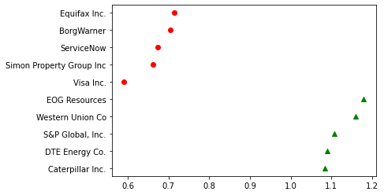

```python
#green companies had values greater than 1 - indicating they are doing better at the end of 2020 compared to the
#beginning
g_companies = []
g_values  = []

#red companies had values less than 1 - indicating they are doing worse at the end of 2020 compared to the
#beginning
r_companies = []
r_values  = []

#place values in correct category
for index, row in re_data.iterrows():
    if row['Price Recovery'] > 1.:
        g_companies.append(row['Name'])
        g_values.append(row['Price Recovery'])
    else:
        r_companies.append(row['Name'])
        r_values.append(row['Price Recovery'])


#populate plot
plt.scatter(g_values, g_companies, marker='^', color='g')
plt.scatter(r_values, r_companies, marker='o', color='r')

#display plot
plt.show()
```

## Real Estate - Market Cap

The next plot compares the price recovery of each of these 10 companies against the market cap of that company

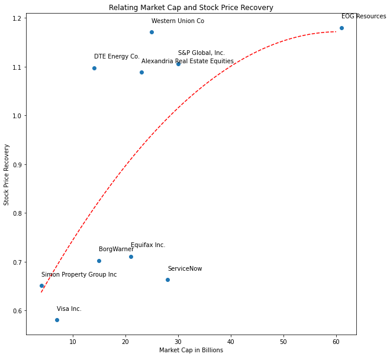

```python
#manipulate market cap data for easier plotting
for index, row in re_data.iterrows():
         re_data['Market Cap'][index] = int(float(row['Market Cap']))

#set plot size
plt.figure(figsize=(10,10))

#plot data
plt.scatter(re_data['Market Cap'], re_data['Price Recovery'])

#label points
for index, row in re_data.iterrows():
    plt.text(row['Market Cap'], row['Price Recovery'] + 0.02, row['Name'])

#label axes and title plot
plt.ylabel('Stock Price Recovery')
plt.xlabel('Market Cap in Billions')
plt.title("Relating Market Cap and Stock Price Recovery")

def fit_func(x, a, b, c):
	return a * x + b * x**2 + c

popt, z= opt.curve_fit(fit_func, re_data['Market Cap'], re_data['Price Recovery'])
a, b, c = popt
x_line = np.arange(min(re_data['Market Cap']), max(re_data['Market Cap']), 1)
y_line = fit_func(x_line, a, b, c)
plt.plot(x_line, y_line, '--', color='red')
```

## Real Estate - Earnings Per Share

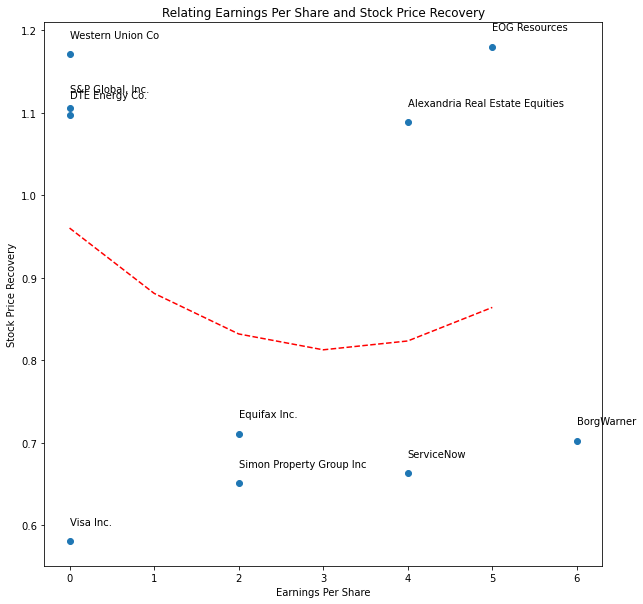

```python
#Note that there is not enough data able for us to be able to perform this computation/analysis for
#every company in our dataframe - we will do it for those that we can

#manipulate earnings per share data for easier plotting
for index, row in re_data.iterrows():
    if row['EPS'] != 'N/A':
        re_data['EPS'][index] = int(float(row['EPS']))
    else:
        re_data = re_data.drop(index)

#set plot size
plt.figure(figsize=(10,10))

#plot data
plt.scatter(re_data['EPS'], re_data['Price Recovery'])

#label points
for index, row in re_data.iterrows():
    plt.text(row['EPS'], row['Price Recovery'] + 0.02, row['Name'])

#label axes and title plot
plt.ylabel('Stock Price Recovery')
plt.xlabel('Earnings Per Share')
plt.title("Relating Earnings Per Share and Stock Price Recovery")

def fit_func(x, a, b, c):
	return a * x + b * x**2 + c

popt, z= opt.curve_fit(fit_func, re_data['EPS'], re_data['Price Recovery'])
a, b, c = popt
x_line = np.arange(min(re_data['EPS']), max(re_data['EPS']), 1)
y_line = fit_func(x_line, a, b, c)
plt.plot(x_line, y_line, '--', color='red')
```

## Real Estate - P/E Ratio

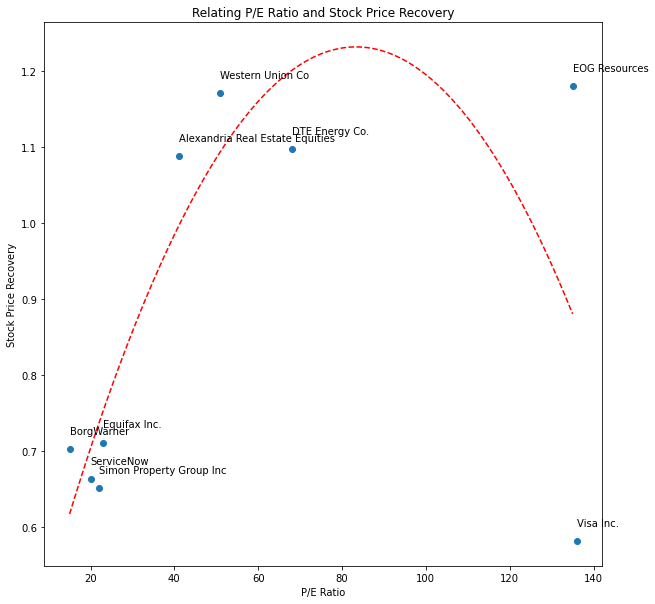

```python
#Note that there is not enough data able for us to be able to perform this computation/analysis for
#every company in our dataframe - we will do it for those that we can

#manipulate earnings per share data for easier plotting
for index, row in re_data.iterrows():
    if row['P/E Ratio'] != 'N/A':
        re_data['P/E Ratio'][index] = int(float(row['P/E Ratio']))
    else:
        re_data = re_data.drop(index)

#set plot size
plt.figure(figsize=(10,10))

#plot data
plt.scatter(re_data['P/E Ratio'], re_data['Price Recovery'])

#label points
for index, row in re_data.iterrows():
    plt.text(row['P/E Ratio'], row['Price Recovery'] + 0.02, row['Name'])

#label axes and title plot
plt.ylabel('Stock Price Recovery')
plt.xlabel('P/E Ratio')
plt.title("Relating P/E Ratio and Stock Price Recovery")

def fit_func(x, a, b, c):
	return a * x + b * x**2 + c

popt, z= opt.curve_fit(fit_func, re_data['P/E Ratio'], re_data['Price Recovery'])
a, b, c = popt
x_line = np.arange(min(re_data['P/E Ratio']), max(re_data['P/E Ratio']), 1)
y_line = fit_func(x_line, a, b, c)
plt.plot(x_line, y_line, '--', color='red')
```

## Energy - Price Visualization

The plot below shows the price change for the top and bottom 5 companies in the energy sector from month to month over the course of 2020

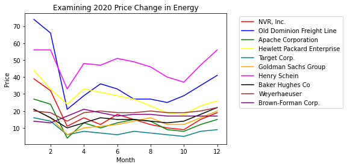

```python
#store coordinates to plot
x = [1,2,3,4,5,6,7,8,9,10,11,12]
e_y = []

#convert y-values to ints for easier use
for i in range(12):
    item = int(float(e_data['Historical Prices'][0][i]))
    e_y.append(item)

plt.plot(x,e_y, color="red", label=e_data['Name'][0])

e_y = []

#convert y-values to ints for easier use
for i in range(12):
    item = int(float(e_data['Historical Prices'][1][i]))
    e_y.append(item)

plt.plot(x,e_y, color="blue", label=e_data['Name'][1])

e_y = []

#convert y-values to ints for easier use
for i in range(12):
    item = int(float(e_data['Historical Prices'][2][i]))
    e_y.append(item)

plt.plot(x,e_y, color="green", label=e_data['Name'][2])

e_y = []

#convert y-values to ints for easier use
for i in range(12):
    item = int(float(e_data['Historical Prices'][3][i]))
    e_y.append(item)

plt.plot(x,e_y, color="yellow", label=e_data['Name'][3])

e_y = []

#convert y-values to ints for easier use
for i in range(12):
    item = int(float(e_data['Historical Prices'][4][i]))
    e_y.append(item)

plt.plot(x,e_y, color="teal", label=e_data['Name'][4])

e_y = []

#convert y-values to ints for easier use
for i in range(12):
    item = int(float(e_data['Historical Prices'][5][i]))
    e_y.append(item)

plt.plot(x,e_y, color="orange", label=e_data['Name'][5])

e_y = []

#convert y-values to ints for easier use
for i in range(12):
    item = int(float(e_data['Historical Prices'][6][i]))
    e_y.append(item)

plt.plot(x,e_y, color="magenta", label=e_data['Name'][6])

e_y = []

#convert y-values to ints for easier use
for i in range(12):
    item = int(float(e_data['Historical Prices'][7][i]))
    e_y.append(item)

plt.plot(x,e_y, color="black", label=e_data['Name'][7])

e_y = []

#convert y-values to ints for easier use
for i in range(12):
    item = int(float(e_data['Historical Prices'][8][i]))
    e_y.append(item)

plt.plot(x,e_y, color="brown", label=e_data['Name'][8])

e_y = []

#convert y-values to ints for easier use
for i in range(12):
    item = int(float(e_data['Historical Prices'][9][i]))
    e_y.append(item)

plt.plot(x,e_y, color="purple", label=e_data['Name'][9])

#label axes and title plot
plt.xlabel("Month")
plt.ylabel("Price")
plt.title("Examining 2020 Price Change in Energy")

#add key
plt.legend(bbox_to_anchor=(1.05, 1), loc="upper left")
```

## Energy - Price Recovery

Next, we will examine the stock price recovery of these 10 companies by plotting the metric that results from dividing a company's December stock price by its January stock price. Using this pre and post coronavirus data in this way will give us company data on a scale relative to the company's original price. This will allow us to see which companies recovered best from the cornovirus market sell offs in the energy sector. Keep in mind that the 10 companies that were chosen to be examined within the sector were chosen based on this metric - we included the 5 best recovered companies and the 5 worst recovered companies.

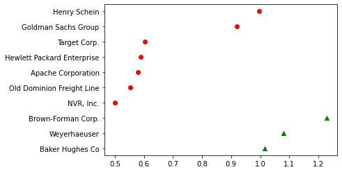

```python
#green companies had values greater than 1 - indicating they are doing better at the end of 2020 compared to the
#beginning
g_companies = []
g_values  = []

#red companies had values less than 1 - indicating they are doing worse at the end of 2020 compared to the
#beginning
r_companies = []
r_values  = []

#place values in correct category
for index, row in e_data.iterrows():
    if row['Price Recovery'] > 1.:
        g_companies.append(row['Name'])
        g_values.append(row['Price Recovery'])
    else:
        r_companies.append(row['Name'])
        r_values.append(row['Price Recovery'])


#populate plot
plt.scatter(g_values, g_companies, marker='^', color='g')
plt.scatter(r_values, r_companies, marker='o', color='r')

#display plot
plt.show()
```

## Energy - Market Cap

The next plot compares the price recovery of each of these 10 companies against the market cap of that company

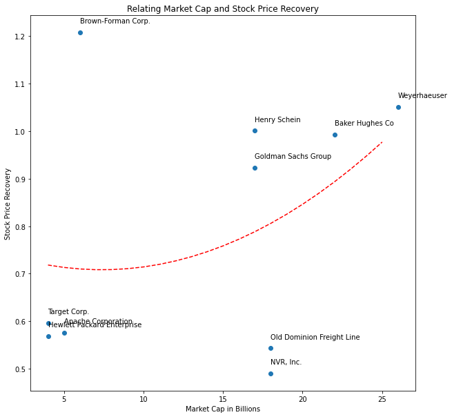

```python
#manipulate market cap data for easier plotting
for index, row in e_data.iterrows():
         e_data['Market Cap'][index] = int(float(row['Market Cap']))

#set plot size
plt.figure(figsize=(10,10))

#plot data
plt.scatter(e_data['Market Cap'], e_data['Price Recovery'])

#label points
for index, row in e_data.iterrows():
    plt.text(row['Market Cap'], row['Price Recovery'] + 0.02, row['Name'])

#label axes and title plot
plt.ylabel('Stock Price Recovery')
plt.xlabel('Market Cap in Billions')
plt.title("Relating Market Cap and Stock Price Recovery")

def fit_func(x, a, b, c):
	return a * x + b * x**2 + c

popt, z= opt.curve_fit(fit_func, e_data['Market Cap'], e_data['Price Recovery'])
a, b, c = popt
x_line = np.arange(min(e_data['Market Cap']), max(e_data['Market Cap']), 1)
y_line = fit_func(x_line, a, b, c)
plt.plot(x_line, y_line, '--', color='red')
```

## Energy - Earnings Per Share

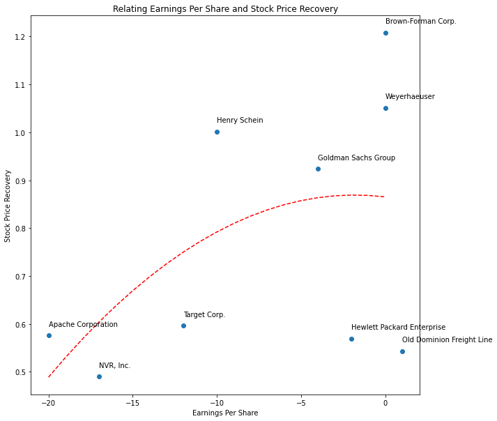

```python
#Note that there is not enough data able for us to be able to perform this computation/analysis for
#every company in our dataframe - we will do it for those that we can

#manipulate earnings per share data for easier plotting
for index, row in e_data.iterrows():
    if row['EPS'] != 'N/A':
        e_data['EPS'][index] = int(float(row['EPS']))
    else:
        e_data = e_data.drop(index)

#set plot size
plt.figure(figsize=(10,10))

#plot data
plt.scatter(e_data['EPS'], e_data['Price Recovery'])

#label points
for index, row in e_data.iterrows():
    plt.text(row['EPS'], row['Price Recovery'] + 0.02, row['Name'])

#label axes and title plot
plt.ylabel('Stock Price Recovery')
plt.xlabel('Earnings Per Share')
plt.title("Relating Earnings Per Share and Stock Price Recovery")

def fit_func(x, a, b, c):
	return a * x + b * x**2 + c

popt, z= opt.curve_fit(fit_func, e_data['EPS'], e_data['Price Recovery'])
a, b, c = popt
x_line = np.arange(min(e_data['EPS']), max(e_data['EPS']), 1)
y_line = fit_func(x_line, a, b, c)
plt.plot(x_line, y_line, '--', color='red')
```

## Energy - P/E Ratio

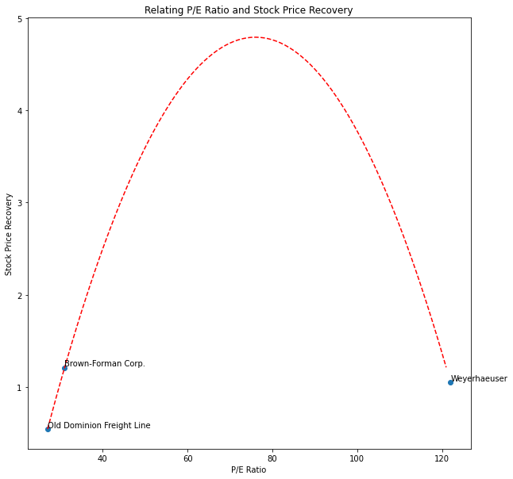

```python
#Note that there is not enough data able for us to be able to perform this computation/analysis for
#every company in our dataframe - we will do it for those that we can

#manipulate earnings per share data for easier plotting
for index, row in e_data.iterrows():
    if row['P/E Ratio'] != 'N/A':
        e_data['P/E Ratio'][index] = int(float(row['P/E Ratio']))
    else:
        e_data = e_data.drop(index)

#set plot size
plt.figure(figsize=(10,10))

#plot data
plt.scatter(e_data['P/E Ratio'], e_data['Price Recovery'])

#label points
for index, row in e_data.iterrows():
    plt.text(row['P/E Ratio'], row['Price Recovery'] + 0.02, row['Name'])

#label axes and title plot
plt.ylabel('Stock Price Recovery')
plt.xlabel('P/E Ratio')
plt.title("Relating P/E Ratio and Stock Price Recovery")

def fit_func(x, a, b, c):
	return a * x + b * x**2 + c

popt, z= opt.curve_fit(fit_func, e_data['P/E Ratio'], e_data['Price Recovery'])
a, b, c = popt
x_line = np.arange(min(e_data['P/E Ratio']), max(e_data['P/E Ratio']), 1)
y_line = fit_func(x_line, a, b, c)
plt.plot(x_line, y_line, '--', color='red')
```

# Conclusions

Overall, it is evident that there are seemingly endless patterns, trends, and influencing factors available to observe when it comes to stocks and how their various aspects fluctuate. One of the most standout observations from our analyses was undoubtedly the striking crash that the energy sector experience towards the beginning of this year. Initial analyses like ours allow for discovery of such occurrences. The next step in the case of such a notable discovery would have been to use statistical investigation to dig deeper into the crash and potentially discover some major causes/influencing factors. These subsequent more in-depth analyses would require more time and more data of course. Another interesting thing to note is that we chose to analyze within sectors by looking at the top and bottom 5 companies in that sector. The determination of how to define ranking ultimately ended up being price recovery ratio for us, which also contributed to interesting analysis. Using that as a ranking metric allows for several strange trends and observations to be made when comparing companies, which tells us that although insightful, maybe using price recovery as a ranking measure was not the best for simply observable patterns due to its peculiar relationship with other stock facets. At the end of the day the two most significant takeaways from this project and our analyses are that the COVID year has had a wide variety of impacts depending on the sector, and the deeper you analyze the more you find to keep investigating!